# Project Proposal: draft due Wednesday, 11/13/2024

You have just completed your literature review, so you now have a good idea about what kind of work has been done in your area of interest. It's now time to put that knowledge to work, and **propose a unique robotics project** that you will complete for your final report in ES302.

# Proposal Guidelines

In terms of structure, we will use the [foolproof research proposal template](https://theprofessorisin.com/2011/07/05/dr-karens-foolproof-grant-template/) from "The Professor is In" (Karen Kelsky). This structure is shown graphically below.

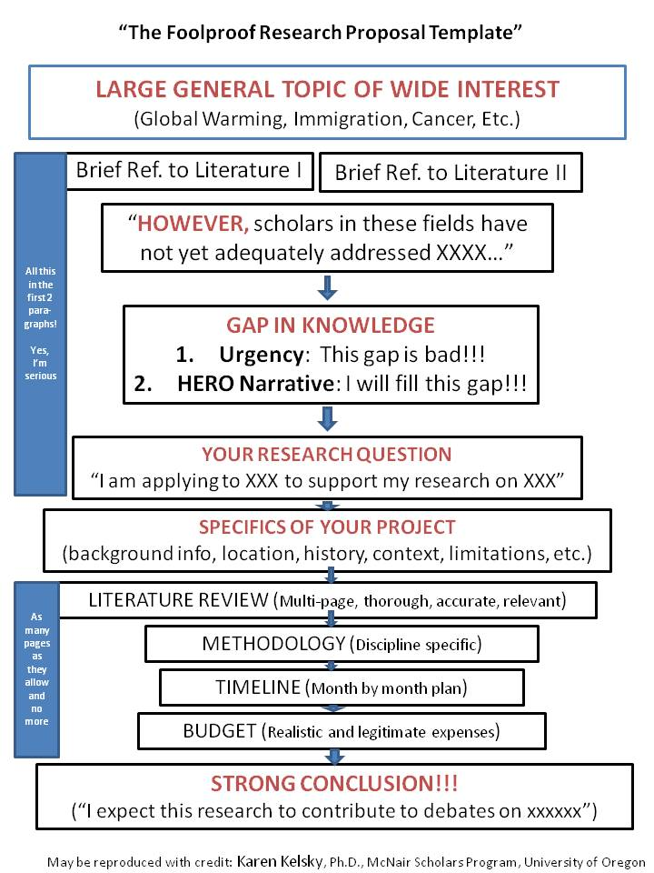

image credit: [Dr. Karen Kelsky, University of Oregon](https://theprofessorisin.com/2011/07/05/dr-karens-foolproof-grant-template/)

We will need to make some modifications to this template so that it is well-suited for ES302.

1. Your "lit review" section will be a condensed, focused version of your work in A06. You may choose to exclude much of your methodology section. The point of this part of the proposal is to explain to readers what has been done in your field.
2. Your "hero narrative" is important, but it is not strictly necessary that you do something that no one has done before. A small modification of work that has been done by someone else is appropriate.
3. You will want to replace your "budget" section with a "required resources" section.
4. You are not "applying to" anything, so modify the language in that section to indicate that you are hoping to complete this project as part of ES302.
5. Your timeline needs to be measured in weeks, not months. We are in week 8 of 14 of the Fall semester already. Develop your timeline accordingly.

## Scoping Your Project

As you think about what you'd like to do for your final project in ES302, I want you to think about:

1. Your capability. What have you learned in ES302? What do we expect to learn (check out the syllabus). How could you use those skills in your proposed project? You will be graded on how and whether you use course concepts in the completion of your project, so this is important. You do not have to use it all, but what we're learning are fundamental skills in robotics, so be sure that you are hitting more than 2 core concepts (such as FSMs, dynamic modeling, coordinate frames, kinematics, control, perception, path planning).
2. Your time. Building a robot in Webots takes me (prof. Brown) about a half of a day. I am not particularly fast with this task, but it will probably take you longer, given my level of experience. You will likely want to budget 12 hours or more just to set up an experiment in Webots using a new robot. Building a real, physical robot that hasn't been designed yet can take easily 10 times that long. This means that you should be sure to keep your robot(s) simple for your experiment, and use Webots whenever possible instead of real hardware.
3. Your field. You've read a lot of work in your field so far. What algorithms do researchers in that field use? Are they compatible with (or replaceable by) concepts we've learned in ES302? How much will you have to learn that's *outside* of what we've covered in order to complete your project? Do those concepts look like things you have the time and capability to learn (with help from me, of course).
4. Your required resources. You **can** propose a hardware experiment, but you should be talking to me first. We have some capability in-house to build new robots, but our budget is limited, and so is our supply of sensors and actuators. If you would like to build a hardware experiment, please let me help you decide whether it is feasible *early* in your process.

If you need help scoping your project, let's talk! It's better to run an idea by me first. If I think it might be too big of a bite, that is good feedback for you!